# Homework 1 - Introduction to R, MLE and LM

SOC 506: Quantitative Techniques in Sociology - Spring 2020

2020-04-07

> All Homowork is to be submitted as an R Markdown HTML document to canvas.

# Question 1

Write an R function that, given a numeric vector $x$ calculates its mean, population variance, and population standard deviation, that is, if $x_i$ are the components of $x$ and $n$ is the length of $x$, then the mean is

$$\mu = 1/n \sum_{i=1}^n x_i$$

and with $\mu$ given by the above the population variance is given by

$$\sigma^2 = (1/n) \sum_{i=1}^n (x_i-\mu)^2$$

and with $\sigma^2$ given by the above the population standard deviation is $\sigma$ (the square root of the variance). Do not use the R functions mean, var, or sd. You may use the R function sum or any other R function in the R core (what is available without using the R function library to attach a package).

Your function should return a list with three components named mean, var, and sd, which are the three things you calculated.

Not only write a function, but also show it working on the data obtained from the [gssr](https://kjhealy.github.io/gssr/) package discussed in lab ($x$) and also on set of randomly generated data ($y$).

```r
library(gssr)
data(gss_panel06_long)
x <- as.numeric(gss_panel06_long$year)
x<-as.numeric(gss_panel06_long$year)[!is.na(x)]
y<-rnorm(200,1,5)
```

## Solution

```r
myR<-5
print(myR)
```

```
[1] 5
```

5 in text. THis is cool!

# Question 2

This is a modification of problem 1. Now we will allow unequal probabilities for the data values. So now we have two vectors of the same length, call them x and p and the latter is a probability vector, meaning its components are nonnegative and sum to one.

If $x_i$ are the components of x and pi are the components of $p$ and $n$ is the length of both $x$ and $p$, then the equations in problem 1 are modified to

$$\mu = \sum_{i=1}^n p_i x_i$$
for the mean, and
$$\sigma^2 = \sum_{i=1}^n (x_i-\mu)^2 p_i$$
for the population variance. As before and as always, the standard deviation is the square root of the variance.

Data for this problem below:

```r
## From gssr example: https://kjhealy.github.io/gssr/articles/overview.html
data(gss_sub)
cont_vars <- c("year", "id", "ballot", "age")

cat_vars <- c("race", "sex", "fefam")

wt_vars <- c("vpsu",
             "vstrat",
             "oversamp",
             "formwt",              # weight to deal with experimental randomization
             "wtssall",             # weight variable
             "sampcode",            # sampling error code
             "sample")              # sampling frame and method

vars <- c(cont_vars, cat_vars, wt_vars)

gss_fam <- gss_sub %>%
  select(c(cont_vars, cat_vars, wt_vars))

test<-data.frame(year=gss_fam$year,w=gss_fam$wtssall^{-1})
test<-data.frame(test,p=test$w/sum(test$w))
head(test)
```

```
  year        w            p
1 1972 2.249213 2.866472e-05
2 1972 1.124480 1.433075e-05
3 1972 1.124480 1.433075e-05
4 1972 1.124480 1.433075e-05
5 1972 1.124480 1.433075e-05
6 1972 2.249213 2.866472e-05
```

This produces a data frame, that is test$year is what we are calling x above and test$p is what we are calling p above. Otherwise, this problem is just like problem 1: write the function and show it working on these data.

# Question 3

## Background

From Charlie’s Basic R Notes (discussed in lecture):

### maximum likelihood estimation

Suppose we want to do maximum likelihood estimation for the gamma distribution with unknown shape parameter and known scale parameter, which we take to be the R default value.

```r
# make up true unknown parameter value ("simulation truth")
alpha <- pi
# make up sample size
n <- 30
# make up data, set RNG seed to get same data every time
set.seed(42)
x <- rgamma(n, shape = alpha)
# log likelihood function
logl <- function(alpha, x)
    sum(dgamma(x, shape = alpha, log = TRUE))
# need interval to optimize over, true "unknown" parameter
# value should be in interval mean(x) + or - 3 * sd(x)
# because E(X) = alpha
interval <- mean(x) + c(-1, 1) * 3 * sd(x)
# but have to not allow non-positive parameter values
interval <- pmax(mean(x) / 1e3, interval)
# maximize the log likelihood
oout <- optimize(logl, maximum = TRUE, interval, x = x)
oout$maximum
```

```
[1] 3.04927
```

```r
mean(x)
```

```
[1] 3.07587
```

The point of showing both the maximum likelihood estimator (MLE) and the sample mean, both of which are consistent and asymptotically normal estimators of the unknown parameter $\alpha$, is just to show that they are different.

A plot of the log likelihood done by the following code

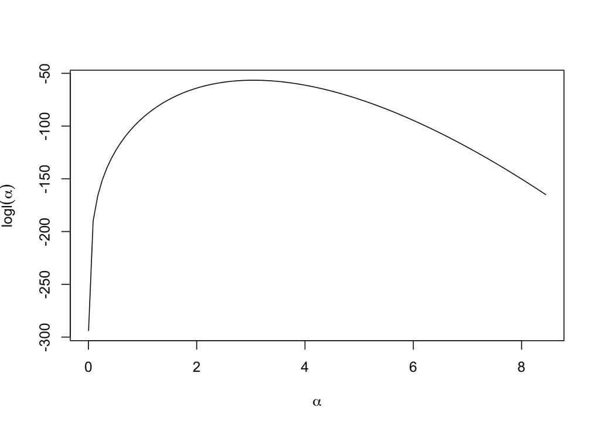

Graph of Log Likelihood

```r
mylogl <- Vectorize(function(alpha) logl(alpha, x))
curve(mylogl, from = interval[1], to = interval[2],
    xlab=expression(alpha), ylab=expression(logl(alpha)))
```

shows that the optimization seems to have worked. The tricks needed to draw this curve we do not want to explain right now.

```
function(arg) f(arg, ...)
```

```
function(arg) f(arg, x = x)
```

or, since `f` is another name for `logl`, as

```
function(arg) logl(arg, x = x)
```

#### alternative solution

The preceding section shows the approved (in some circles) way to do that problem.

But here is another way (that some people deem evil and stupid). Just define `logl` as a function of one variable.

```r
logl <- function(alpha)
    sum(dgamma(x, shape = alpha, log = TRUE))
```

and then do the optimization as before except now we omit the `x = x`.

```r
oout <- optimize(logl, maximum = TRUE, interval)
oout$maximum
```

```
[1] 3.04927
```

How does that work? How does `logl` when called from within `optimize` find out what `x` is?

The short answer is that it looks it up in the R global environment (which is where we defined it in the first place). So it works. And we didn’t need `x = x`.

And now for the caution about this method. [Global variables are evil](http://wiki.c2.com/?GlobalVariablesAreBad). (An interesting bit of computing history: Wiki Wiki Web was the first Wiki that Wikipedia and zillions of other wikis copy ([Wikipedia entry Wiki](https://en.wikipedia.org/w/index.php?title=Wiki&oldid=752613214)).

In serious work, global variables should never be used. Especially, they should never be used in code that you make for others to use. What if you call the data `x` inside your function and the user calls the data `y` outside your function. That won’t work. But if the `...` trick is used, then the user can still call the data `y` and make the argument to match `x` via the `...` mechanism `x = y`, that is, the argument named `x` (in the function you wrote) is the data named `y` (outside the function) by the user.

So put `logl` back the way it was originally

```r
logl <- function(alpha, x)
    sum(dgamma(x, shape = alpha, log = TRUE))
```

and now call the data `y`

```r
y <- x
rm(x) # now x is gone
```

and

```r
oout <- optimize(logl, maximum = TRUE, interval, x = y)
oout$maximum
```

```
[1] 3.04927
```

still works.

You only need to avoid global variables to be politically correct in the computer science sense (as the Wiki Wiki Web page cited above explains) or to have your code usable by others (including your future self six months from now).

## Part 1

Modify the calculations of the above so that they are done by one R function.

Your R function will have one argument, which is the data (x in the example in the notes) and will produce one scalar value, which is the MLE (maximum likelihood estimate) (oout$maximum in the example in the notes).

For this problem you can use the easier method because inside your function x is not a global variable (hence not evil) because it is a local variable in your function.

Not only write a function, but also show it working on the data obtained by the R command

```r
x <- scan(url("http://www.stat.umn.edu/geyer/3701/data/q1p3.txt"))
```

## Part 2

Write an R function that has three arguments the data vector x, just like before, a function that itself has two arguments,the (univariate) parameter theta and the data vector x, and an interval over which to search given by a vector of length two called interval.

The function is supposed to return the log of the probability density function (PDF) or probability mass function (PMF), depending on whether the distribution of x is contiuous or discrete, respectively. (The reason we have the user supply the interval because there is no way we can tell what the range of values of the parameter is). One example of such a function is

```r
function(theta, x) dgamma(x, shape = theta, log = TRUE)
```

that we used in our function but another would be

```r
function(theta, x) dcauchy(x, location = theta, log = TRUE)
```

and yet another would be

```r
function(theta, x) dbinom(x, 20, prob = 1 / (1 + exp(- theta)), log = TRUE)
```

The idea is that the user provides a function for whatever the distribution the user wants. Modify your answer to first problem so it works as described here.

If you use the gamma PDF function above as your function argument, then the data for problem 3 are appropriate.

If you use the Cauchy PDF function above as your function argument, then the following data are appropriate

```r
x <- scan(url("http://www.stat.umn.edu/geyer/3701/data/q1p7c.txt"))
```

If you use the binomial PMF function above as your function argument, then the following data are appropriate

```r
x <- scan(url("http://www.stat.umn.edu/geyer/3701/data/q1p7b.txt"))
```

The parameter spaces are $0$ to $\infty$ for gamma, $-\infty$ to $\infty$ for Cauchy and binomial. But I assure you that the true unknown parameter values are less than 10 in absolute value and, for the gamma, greater than 0.1. You are relying on the user of your function to get this right, but while testing your function you have to play the role of the user.

Show that your function works with all three of the user-supplied functions given above.

# Question 4

### Part 1

Using the [gssr](https://kjhealy.github.io/gssr/) package. Use tidyverse methods to generate a data set from `gss_panel06_long` with variables `c("age","sex","race","income","income06","rincome","vote00","vote04","vote08")`.

### Part 2

Use tidyverse to generate summary table for this data set (mean, sd, max, min, count).

### Part 3

Fit linear model using `lm` for `rincome` on `vote00`. Include some control variables and justify your final model. *Hint* Justify your model with some sort of analytic technique.

### Part 4

Check the assumptions of your model. Justify your choice of model diagnostics.

### Part 5

Interpret your final model.